# Reproducible research compendium through GitHub and RStudio

Greg Chism

2022/Aug/22

# Introduction

[figure not shown]

## Research is increasingly computational

- **Code and data are important research outputs**
  - Yet, we mainly on publishing papers.
- **Calls for openness**
  - Stick: we have a reproducibility crisis
  - Carrot: open science promotes equity and collaboration

#### We however lack the means for such openness.

## Enter the Research Compendium

> The goal of a research compendium is to provide a **standard** and easily recognizable way for **organizing the digital materials** of a project to enable others to **inspect, reproduce, and extend the research**.

### Three Generic Principles

1. **Organize files according to best practices**
   - Help others understand the structure of your project.
   - Supports tool building which takes advantage of the shared structure.
2. **Separate of data, method, and output**, while making the relationship between them clear.
3. **Specify the computational environment** that was used for the original analysis.

## R community response

> R packages can be used as a research compendium for organizing and sharing files!
1. _Wickham, H. (2017) [Research compendia. Note prepared for the 2017 rOpenSci Unconf](https://docs.google.com/document/d/1LzZKS44y4OEJa4Azg5reGToNAZL0e0HSUwxamNY7E-Y/edit#heading=h.blggi16hdosp)
2. Ben Marwick, Carl Boettiger & Lincoln Mullen (2018) [*Packaging Data Analytical Work Reproducibly Using R (and Friends)*](https://www.tandfonline.com/doi/abs/10.1080/00031305.2017.1375986?journalCode=utas20), The American Statistician, 72:1, 80-88, DOI: <10.1080/00031305.2017.1375986>

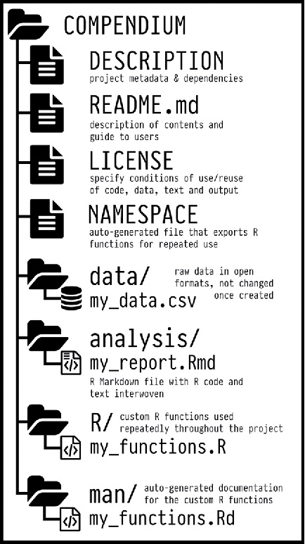

## Enter `rrtools`

> The goal of **`rrtools`** is to provide **instructions, templates, and functions** for making a **template compendium** suitable for producing **reproducible research with R**.

**`rrtools` build on tools & best practices for R package development to**

- Organize files
- Manage dependencies
- Share code
- Document code
- Check and test code *where applicable*

**`rrtools` extends and works with a number of R packages:**

- [`devtools`](https://cran.r-project.org/package=devtools): functions for package development
- [`usethis`](https://www.tidyverse.org/articles/2017/11/usethis-1.0.0/): automates repetitive tasks that arise during project setup and development
- [`bookdown`](https://bookdown.org/): facilitates writing books and long-form articles/reports with R Markdown

# Workshop approach

## Live coding

I practice **live coding** 😨 during my workshops so that you can follow along and have your version of the R scripts.

However, the materials in this book will help you along the way!

# Workshop materials

#### On github: [https://github.com/gchism/rrtools-wkshp-materials/](https://github.com/Gchism94/rrtools-repro-research)

- Click on **Fork**
- Click on **Clone** within the new repository
- Copy the **HTTPS URL**
- Start a new **RStudio Project** in RStudio Cloud using **Version control**
- Paste the **Link**
- Click **Start Project**

# Workshop aims and objectives

In these workshops we’ll **create a template research compendium** that you can use for your own research project (text, data, code).

By the end of the workshop, you should be able to:

- Be able to **Create a Research Compendium** to manage and share resources associated with an academic publication.
- Be able to **produce a reproducible manuscript from a single Rmarkdown document**.
- (**If there’s interest**) Understand the basics of **managing code as an R package**.
- Appreciate the power of convention!

> It’s like agreeing that we will all drive on the left or the right. A hallmark of civilization is following conventions that constrain your behavior a little, in the name of public safety.

**Jenny Bryan** on [Project-oriented workflows](https://www.tidyverse.org/articles/2017/12/workflow-vs-script/)

### Level

Intermediate

### Prerequisites:

Familiarity with Version Control through RStudio and rmarkdown.

### System Requirements:

Pandoc (>= 1.17.2) LaTeX

If you don’t have LaTeX installed, consider installing `TinyTeX`, a custom LaTeX distribution based on TeX Live that is small in size but functions well in most cases, especially for R users.

Check [docs](https://yihui.name/tinytex/) before before installing.